# ICT 782 - Day 9 Notes

# Linear Regression

Today we'll discuss one of the most commonly used analysis techniques: **linear regression**. There are many aspects to this technique, and we'll only be able to focus on highlights in this lesson. However, if you're interested in learning more about regression, I can recommend the following resources, which I'll also cite throughout the lesson:

- Introduction to Statistical Learning with Applications in R by Gareth James et al.- the price of this book completely belies its utility: the book is *free*! Find the book, R package, and code [here](http://faculty.marshall.usc.edu/gareth-james/ISL/).
- A Second Course in Statistics: Regression Analysis by William Mendenhall and Terry Sincich - a more formal take on regression, this book is comprehensive in its exposition of the topic. This book also provides an extremely useful chapter on regression pitfalls.
- Elements of Statistical Learning by Trevor Hastie, Robert Tibrishani, and Jerome Friedman - another surprisingly *free* book that covers a wealth of information on multiple 'machine learning' techniques, including linear regression. This book assumes a background in statistics and linear algebra, but attempts to stay mostly self-contained. Find the book and code samples [here](https://web.stanford.edu/~hastie/ElemStatLearn/).

```python
import numpy as np
import pandas as pd
import matplotlib.pyplot as plt
from sklearn.model_selection import train_test_split
```

# Linear relationships

To say that two random variables from a dataset are *linearly* related is to say that if we made a scatterplot of the two variables, we could draw a straight line that would approximately 'fit' the data. It is our goal today to understand what 'fit' means in this context.

Consider the following code cell which plots the two variables `X` and `Y`. The resulting plot shows that `X` and `Y` are linearly related, and the drawn line roughly 'fits' the data.

**Note:** Yes, there is an 'xkcd' style in Matplotlib that makes plots look like the popular comics.

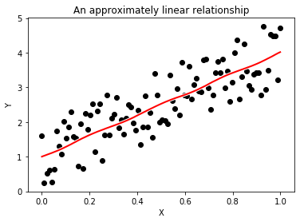

```python
b0 = 2*np.random.rand(100)
b1 = 3

X = np.linspace(0,1,100)
Y = b1*X + b0

fig, ax = plt.subplots()

ax.scatter(X, Y, color = 'k');

with plt.xkcd(scale = 1, length = 100, randomness = 2):
    x1 = [0,1]
    line = [1,4]
    ax.plot(x1, line, color = 'r');
ax.set(title = 'An approximately linear relationship',
       xlabel = 'X',
       ylabel = 'Y');
```

Since the relationship between the variables is approximately linear, we can 'draw' a straight line that is, on average, equally close to every data point.

Mathematically, we would say that we are trying to 'minimize the sum of the squared errors'. We'll put this into notation in the next section.

# Simple linear regression

As we discussed on Day 5, simple linear regression assumes that two random variables $X$ and $Y$ are linearly related. In other words, we assume that $$ y \approx \beta_0 + \beta_1x, $$ for all $x$ and $y$ pairs in the respective data columns $X$ and $Y$, and where we use $\approx$ instead of $=$ to account for random variability in the data. Based on the data, we make an *estimate* of $y$-values that would follow an exactly linear relationship. We define this second linear relationship or **model** as $$ \hat{y} = \hat{\beta_0} + \hat{\beta_1}x. $$

We use equality in this expression, since this will give us the equation for our line. The `^` (hat or 'carat') symbol represents the fact that these parameters are estimates. We estimate the parameters $\hat{\beta_0}$ and $\hat{\beta_1}$ by minimizing the sum of the squared errors, which is given by $$ \sum (y - \hat{y})^2, $$ where the sum is taken over all $x,y$ pairs in the columns $X$ and $Y$. We often see this called the 'residual sum of squares' or 'RSS', and so we'll refer to it by RSS. If you want to find the minimum, you can take the derivative, set it to zero, and solve for the minimizer (but let's allow Python to do that for us).

We will also refer to the total sum of squares or TSS, which is defined by $$ TSS = \sum (y - \bar{y})^2, $$ where $\bar{y}$ is the mean of the $y$-values. Notice that this is almost exactly the expression for the variance of the $y$ variable (the variance takes the extra step of dividing by the number of observations).

## Testing the model

We first test the parameter $\beta_1$ for statistical significance. Only the $\beta_1$ parameter needs to be tested, since it is the only parameter involving $X$. Expressed as a formal hypothesis test, this test can be written as $$ H_0 : \beta_1 = 0, \quad H_a : \beta_1 \neq 0. $$

The actual testing is done by checking the $t$ statistic for the $\hat{\beta}$ parameter, which comes with a corresponding confidence interval and a $p$-value. The $p$-value is the probability of seeing the given $t$-statistic, and the parameter is usually said to be significant if $p < 0.05$ (95% confidence). Note that the intercept may similarly be tested for significance.

Next, we can measure the proportion of variability accounted for by our model. This proportion is calculated by the following ratio: $$ \frac{TSS - RSS}{TSS} =: R^2. $$

Higher values of $R^2$ correspond to a higher percentage of variability being explained by our model ($0 \leq R^2 \leq 1$).

Let's take a look at an example and see where these numbers are displayed in the output. We have two options for fitting linear regression models: sklearn and statsmodels. We'll use both in the example.

# *Example:* Linear regression with admissions data

Do GRE scores influence the chance of being admitted to graduate school? A generous research group from India (Acharya, Armaan, & Antony, 2019) has kindly made available data on [Kaggle](https://www.kaggle.com/mohansacharya/graduate-admissions). This dataset has been used in numerous open source projects for regression and contains 500 observations with several variables recorded from graduate studies applicants. The variables in this dataset are:

- `GRE Score` - out of 340
- `TOEFL Score` - out of 120
- `University Rating` - out of 5
- `SOP` - statement of purpose strength (out of 5)
- `LOR` - letter of recommendation strength (out of 5)
- `CGPA` - Undergraduate GPA (out of 10)
- `Research` - research experience (either 0 or 1)
- `Chance of Admit` - ranging from 0 to 1

We'll consider `GRE Score = X` and `Chance of Admit = Y`. First we'll make a plot of the data to see if a linear relationship is even plausible.

```python
data = pd.read_csv('admission_predict.csv', index_col = 0)

# Remove leading and trailing spaces in the column names
data.columns = data.columns.str.strip()
data
```

| Serial No. | GRE Score | TOEFL Score | University Rating | SOP | LOR | CGPA | Research | Chance of Admit |
| --- | --- | --- | --- | --- | --- | --- | --- | --- |
| 1 | 337 | 118 | 4 | 4.5 | 4.5 | 9.65 | 1 | 0.92 |
| 2 | 324 | 107 | 4 | 4.0 | 4.5 | 8.87 | 1 | 0.76 |
| 3 | 316 | 104 | 3 | 3.0 | 3.5 | 8.00 | 1 | 0.72 |
| 4 | 322 | 110 | 3 | 3.5 | 2.5 | 8.67 | 1 | 0.80 |
| 5 | 314 | 103 | 2 | 2.0 | 3.0 | 8.21 | 0 | 0.65 |
| ... | ... | ... | ... | ... | ... | ... | ... | ... |
| 496 | 332 | 108 | 5 | 4.5 | 4.0 | 9.02 | 1 | 0.87 |
| 497 | 337 | 117 | 5 | 5.0 | 5.0 | 9.87 | 1 | 0.96 |
| 498 | 330 | 120 | 5 | 4.5 | 5.0 | 9.56 | 1 | 0.93 |
| 499 | 312 | 103 | 4 | 4.0 | 5.0 | 8.43 | 0 | 0.73 |
| 500 | 327 | 113 | 4 | 4.5 | 4.5 | 9.04 | 0 | 0.84 |

500 rows × 8 columns

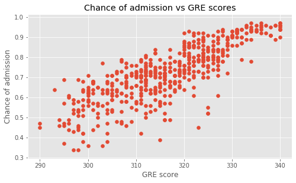

```python
X = data['GRE Score']
Y = data['Chance of Admit']

plt.style.use('ggplot')
fig, ax = plt.subplots(figsize = (8, 4.5))

ax.scatter(X, Y);
ax.set(title = 'Chance of admission vs GRE scores',
       xlabel = 'GRE score',
       ylabel = 'Chance of admission');
```

It looks like there is a linear relationship here, so we'll go ahead and fit the linear regression.

### Method 1: Using sklearn

```python
from sklearn.linear_model import LinearRegression
import statsmodels.api as sm
from statsmodels.formula.api import ols
```

```python
# Saving 40% of the data for testing
train, test = train_test_split(data, test_size = 0.4)

X_train = train['GRE Score']
Y_train = train['Chance of Admit']

X_test = test['GRE Score']
Y_test = test['Chance of Admit']

# sklearn wants only 2D arrays for X
X_train = np.array(X_train).reshape(-1,1)
X_test = np.array(X_test).reshape(-1,1)
```

```python
model1 = LinearRegression()
model1.fit(X_train, Y_train)

# Display the beta parameters from the model
b0 = model1.intercept_
b1 = model1.coef_

print('Model parameters:')
print('b0 = {}'.format(b0))
print('b1 = {}'.format(b1[0]))

# Display the R^2 value
print('R^2 = {:.4f}'.format(model1.score(X_train, Y_train)))
```

```
Model parameters:
b0 = -2.5728340514422388
b1 = 0.01040469101637981
R^2 = 0.6791
```

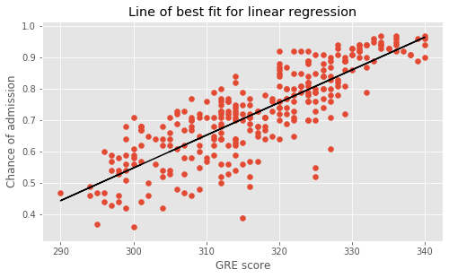

```python
# Plotting the line of best fit
Y_pred = model1.predict(X_test)

fig, ax = plt.subplots(figsize = (8, 4.5))

ax.scatter(X_train, Y_train)
ax.plot(X_test, Y_pred, color = 'k');
ax.set(title = 'Line of best fit for linear regression',
       xlabel = 'GRE score',
       ylabel = 'Chance of admission');
```

### Method 2: Using statsmodels

Using sklearn is fast and easy, but statsmodels provides a much richer output, including $t$-statistics and $p$-values.

```python
train = train[['GRE Score','Chance of Admit']]
test = test[['GRE Score','Chance of Admit']]

train.columns = ['X','Y']
test.columns = ['X','Y']

# We must tell the model to fit the intercept, so we add a constant to our data
train = sm.add_constant(train)
test = sm.add_constant(test)
train
```

| Serial No. | const | X | Y |
| --- | --- | --- | --- |
| 395 | 1.0 | 329 | 0.89 |
| 483 | 1.0 | 328 | 0.83 |
| 450 | 1.0 | 315 | 0.79 |
| 136 | 1.0 | 314 | 0.82 |
| 88 | 1.0 | 317 | 0.66 |
| ... | ... | ... | ... |
| 412 | 1.0 | 313 | 0.56 |
| 498 | 1.0 | 330 | 0.93 |
| 361 | 1.0 | 322 | 0.85 |
| 489 | 1.0 | 322 | 0.76 |
| 110 | 1.0 | 304 | 0.68 |

300 rows × 3 columns

```python
import statsmodels
statsmodels.__version__
```

```
'0.11.0'
```

```python
model2 = ols('Y ~ X', data = train).fit()
print(model2.summary())
```

```
                            OLS Regression Results
==============================================================================
Dep. Variable:                      Y   R-squared:                       0.679
Model:                            OLS   Adj. R-squared:                  0.678
Method:                 Least Squares   F-statistic:                     630.6
Date:                Wed, 25 Mar 2020   Prob (F-statistic):           1.58e-75
Time:                        18:56:10   Log-Likelihood:                 331.30
No. Observations:                 300   AIC:                            -658.6
Df Residuals:                     298   BIC:                            -651.2
Df Model:                           1
Covariance Type:            nonrobust
==============================================================================
                 coef    std err          t      P>|t|      [0.025      0.975]
------------------------------------------------------------------------------
Intercept     -2.5728      0.131    -19.590      0.000      -2.831      -2.314
X              0.0104      0.000     25.112      0.000       0.010       0.011
==============================================================================
Omnibus:                       30.608   Durbin-Watson:                   2.099
Prob(Omnibus):                  0.000   Jarque-Bera (JB):               38.642
Skew:                          -0.749   Prob(JB):                     4.06e-09
Kurtosis:                       3.920   Cond. No.                     8.96e+03
==============================================================================

Warnings:
[1] Standard Errors assume that the covariance matrix of the errors is correctly specified.
[2] The condition number is large, 8.96e+03. This might indicate that there are
strong multicollinearity or other numerical problems.
```

# Interpreting the regression output

The `summary()` method for the `ols` object provides us with a wealth of information about our model. On the upper left, we see basic information such as the dependent variable, the model and method for fitting, the date and time, and the degrees of freedom.

On the upper right, we see the $R^2$ value discussed above. Immediately below $R^2$ is a value called `Adj. R-squared`, sometimes denoted as $R_a^2$. This value accounts for the number of predictor variables in the model. It has been discovered that $R^2$ will automatically increase when more predictors are added to the model, and $R_a^2$ corrects for this phenomenon. Often the $R_a^2$ value is reported along with $R^2$, as it is a less biased measure of the amount of variability accounted for by the model.

Below $R_a^2$, we see the `F-statistic` and `Prob (F-statistic)`. We saw this statistic when we talked about ANOVA on Day 4. The `F-statistic` can be described by: $$ F = \frac{\text{explained variance}}{\text{unexplained variance}}. $$ In other words, when the `F-statistic` is large, the model explains more of the variance in the data. The corresponding $p$-value for the `F-statistic` is found in `Prob (F-statistic)`. We say that the *model is statistically significant* if `Prob (F-statistic) < 0.05`.

### Technical outputs

Next on the upper right of the output are the `Log-Likelihood`, `AIC`, and `BIC`. These are much more technical in nature, but can be simply summarized as follows. The `Log-Likelihood` is the quantity maximized during maximum likelihood estimation. Higher values are better.

The Akaike Information Criterion, or `AIC`, is used when selecting which predictor variables are important for the model. When `AIC` is lower, that means the model is getting closer to representing the truth. Similarly, when the Bayesian Information Criterion, or `BIC`, is lower, then the model is getting closer to representing the truth.

For further reading on this, a good place to start is [Wikipedia](https://en.wikipedia.org/wiki/Akaike_information_criterion).

### Model parameters

After these statistics we see tabular output for `Intercept` and `X`. The `coef` column contains the *coefficients* or parameter values for $\hat{\beta_0}$ and $\hat{\beta_1}$, respectively (recalling that our model was $\hat{y} = \hat{\beta_0} + \hat{\beta_1}x$, where $\hat{\beta_0}$ is the *intercept* and $\hat{\beta_1}$ is the *slope* of the regression line).

```python
print(model2.summary())
```

```
                            OLS Regression Results
==============================================================================
Dep. Variable:                      Y   R-squared:                       0.679
Model:                            OLS   Adj. R-squared:                  0.678
Method:                 Least Squares   F-statistic:                     630.6
Date:                Wed, 25 Mar 2020   Prob (F-statistic):           1.58e-75
Time:                        19:04:55   Log-Likelihood:                 331.30
No. Observations:                 300   AIC:                            -658.6
Df Residuals:                     298   BIC:                            -651.2
Df Model:                           1
Covariance Type:            nonrobust
==============================================================================
                 coef    std err          t      P>|t|      [0.025      0.975]
------------------------------------------------------------------------------
Intercept     -2.5728      0.131    -19.590      0.000      -2.831      -2.314
X              0.0104      0.000     25.112      0.000       0.010       0.011
==============================================================================
Omnibus:                       30.608   Durbin-Watson:                   2.099
Prob(Omnibus):                  0.000   Jarque-Bera (JB):               38.642
Skew:                          -0.749   Prob(JB):                     4.06e-09
Kurtosis:                       3.920   Cond. No.                     8.96e+03
==============================================================================

Warnings:
[1] Standard Errors assume that the covariance matrix of the errors is correctly specified.
[2] The condition number is large, 8.96e+03. This might indicate that there are
strong multicollinearity or other numerical problems.
```

### Other statistics

Next, we see the `Omnibus` statistic with its corresponding $p$-value `Prob(Omnibus)`. This tests the normality of the *residuals*, which are defined by the prediction error in the predicted $y$ values. The `Skew` and `Kurtosis` parameters are the fitted parameters for a normal distribution.

The `Durbin-Watson` statistic is mainly used in time series, and won't be discussed here. The `Jarque-Bera (JB)` statistic is another test for the normality of the residuals, and comes with its $p$-value `Prob(JB)`.

Finally, the `Cond. No.` is the *condition number* of the $X^TX$ matrix. Further implications of this number won't be discussed here.

## Plotting the results

The above information goes to show that statsmodels provides a much broader output than sklearn for regression. We can also get a rich visualization of our regression results by plotting the confidence and prediction intervals for our predicted $\hat{y}$ values.

To get the confidence and prediction intervals for our model, we use the aptly named `get_prediction(<test set>).summary_frame(1 - <confidence level>)` method for the `ols` object. This returns a `DataFrame` with 6 columns as follows.

- `mean` - the predicted $\hat{y}$ value
- `mean_se` - standard error for `mean`
- `mean_ci_upper` and `mean_ci_lower` - the respective upper and lower limits of the confidence interval
- `obs_ci_upper` and `obs_ci_lower` - the respective upper and lower limits of the prediction interval

Let's compute these predictions and plot the results.

```python
# This obtains the predicted Y values as well as their confidence intervals
predictions = model2.get_prediction(test[['X','const']]).summary_frame(alpha = 0.05)
predictions
```

|  | mean | mean_se | mean_ci_lower | mean_ci_upper | obs_ci_lower | obs_ci_upper |
| --- | --- | --- | --- | --- | --- | --- |
| 0 | 0.600597 | 0.006740 | 0.587332 | 0.613861 | 0.441689 | 0.759505 |
| 1 | 0.798286 | 0.005524 | 0.787415 | 0.809157 | 0.639560 | 0.957012 |
| 2 | 0.652620 | 0.005430 | 0.641933 | 0.663307 | 0.493906 | 0.811334 |
| 3 | 0.673430 | 0.005051 | 0.663489 | 0.683370 | 0.514764 | 0.832095 |
| 4 | 0.725453 | 0.004647 | 0.716309 | 0.734597 | 0.566836 | 0.884070 |
| ... | ... | ... | ... | ... | ... | ... |
| 195 | 0.871119 | 0.007501 | 0.856357 | 0.885880 | 0.712079 | 1.030159 |
| 196 | 0.756667 | 0.004833 | 0.747156 | 0.766178 | 0.598028 | 0.915306 |
| 197 | 0.673430 | 0.005051 | 0.663489 | 0.683370 | 0.514764 | 0.832095 |
| 198 | 0.631811 | 0.005902 | 0.620195 | 0.643426 | 0.473032 | 0.790590 |
| 199 | 0.558978 | 0.008023 | 0.543189 | 0.574767 | 0.399839 | 0.718117 |

200 rows × 6 columns

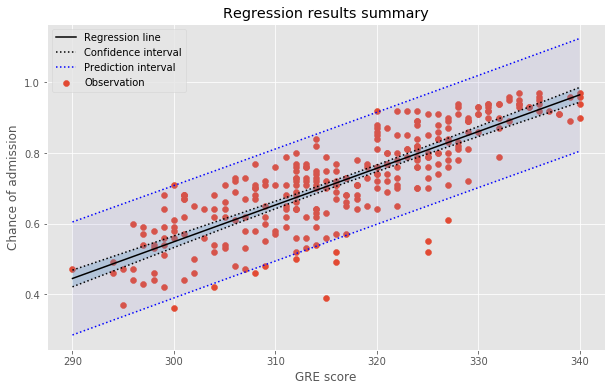

```python
# This defines the regression line
Y_pred = predictions['mean'].sort_values()

# These define the 95% confidence interval
ci_upper = predictions['mean_ci_upper'].sort_values()
ci_lower = predictions['mean_ci_lower'].sort_values()

# These define the prediction interval
pi_upper = predictions['obs_ci_upper'].sort_values()
pi_lower = predictions['obs_ci_lower'].sort_values()

X_plot = test['X'].sort_values()

fig, ax = plt.subplots(figsize = (10,6))

# Plot the observations
ax.scatter(train['X'], train['Y'], marker = 'o', label = 'Observation');

# Plot the regression line
ax.plot(X_plot, Y_pred, 'k', label = 'Regression line');

# Plot the confidence interval
ax.plot(X_plot, ci_upper, 'k:');
ax.plot(X_plot, ci_lower, 'k:', label = 'Confidence interval');

# Plot the prediction interval
ax.plot(X_plot, pi_upper, 'b:');
ax.plot(X_plot, pi_lower, 'b:', label = 'Prediction interval');

plt.fill_between(X_plot, ci_lower, ci_upper, alpha = 0.25);
plt.fill_between(X_plot, pi_lower, pi_upper, alpha = 0.15);

ax.set(title = 'Regression results summary',
       xlabel = 'GRE score',
       ylabel = 'Chance of admission');
ax.legend();
```

# Multiple linear regression

Multiple regression involves using more than one predictor variable (often called *features*) to estimate the *target* variable $Y$. All of the above information for simple linear regression remains for multiple regression, only now we assume the expanded linear relationship $$ y \approx \beta_0 + \beta_1x_1 + \beta_2x_2 + \cdots + \beta_px_p, $$ where $X = \{ x_1,x_2,\ldots,x_p \}$ represent the columns of predictor variables. We then fit the model $$ \hat{y} = \hat{\beta_0} + \hat{\beta_1}x_1 + \hat{\beta_2}x_2 + \cdots + \hat{\beta_p}x_p. $$

# *Example:* Multiple linear regression

We'll now fit the model above to all variables in the admissions dataset.

```python
data = pd.read_csv('admission_predict.csv', index_col = 0)

# Remove leading and trailing spaces in the column names
data.columns = ['GRE','TOEFL','Rating','SOP','LOR','CGPA','Research','Y']

# Adding the constant
data = sm.add_constant(data)
data
```

| Serial No. | const | GRE | TOEFL | Rating | SOP | LOR | CGPA | Research | Y |
| --- | --- | --- | --- | --- | --- | --- | --- | --- | --- |
| 1 | 1.0 | 337 | 118 | 4 | 4.5 | 4.5 | 9.65 | 1 | 0.92 |
| 2 | 1.0 | 324 | 107 | 4 | 4.0 | 4.5 | 8.87 | 1 | 0.76 |
| 3 | 1.0 | 316 | 104 | 3 | 3.0 | 3.5 | 8.00 | 1 | 0.72 |
| 4 | 1.0 | 322 | 110 | 3 | 3.5 | 2.5 | 8.67 | 1 | 0.80 |
| 5 | 1.0 | 314 | 103 | 2 | 2.0 | 3.0 | 8.21 | 0 | 0.65 |
| ... | ... | ... | ... | ... | ... | ... | ... | ... | ... |
| 496 | 1.0 | 332 | 108 | 5 | 4.5 | 4.0 | 9.02 | 1 | 0.87 |
| 497 | 1.0 | 337 | 117 | 5 | 5.0 | 5.0 | 9.87 | 1 | 0.96 |
| 498 | 1.0 | 330 | 120 | 5 | 4.5 | 5.0 | 9.56 | 1 | 0.93 |
| 499 | 1.0 | 312 | 103 | 4 | 4.0 | 5.0 | 8.43 | 0 | 0.73 |
| 500 | 1.0 | 327 | 113 | 4 | 4.5 | 4.5 | 9.04 | 0 | 0.84 |

500 rows × 9 columns

```python
train, test = train_test_split(data, test_size = 0.4)

X_train = train.drop('Y', axis = 1)
Y_train = train['Y']

X_test = test.drop('Y', axis = 1)
Y_test = test['Y']
```

```python
model3 = ols('Y ~ GRE + TOEFL + Rating + SOP + LOR + CGPA + Research', data = train).fit()
print(model3.summary())
```

```
                            OLS Regression Results
==============================================================================
Dep. Variable:                      Y   R-squared:                       0.805
Model:                            OLS   Adj. R-squared:                  0.800
Method:                 Least Squares   F-statistic:                     172.1
Date:                Wed, 25 Mar 2020   Prob (F-statistic):           1.13e-99
Time:                        19:20:18   Log-Likelihood:                 410.75
No. Observations:                 300   AIC:                            -805.5
Df Residuals:                     292   BIC:                            -775.9
Df Model:                           7
Covariance Type:            nonrobust
==============================================================================
                 coef    std err          t      P>|t|      [0.025      0.975]
------------------------------------------------------------------------------
Intercept     -1.2574      0.143     -8.815      0.000      -1.538      -0.977
GRE            0.0020      0.001      2.958      0.003       0.001       0.003
TOEFL          0.0028      0.001      2.421      0.016       0.001       0.005
Rating         0.0088      0.005      1.711      0.088      -0.001       0.019
SOP            0.0009      0.006      0.144      0.885      -0.011       0.013
LOR            0.0196      0.005      3.570      0.000       0.009       0.030
CGPA           0.1073      0.013      8.423      0.000       0.082       0.132
Research       0.0234      0.009      2.643      0.009       0.006       0.041
==============================================================================
Omnibus:                       58.799   Durbin-Watson:                   1.933
Prob(Omnibus):                  0.000   Jarque-Bera (JB):              114.826
Skew:                          -1.024   Prob(JB):                     1.16e-25
Kurtosis:                       5.234   Cond. No.                     1.32e+04
==============================================================================

Warnings:
[1] Standard Errors assume that the covariance matrix of the errors is correctly specified.
[2] The condition number is large, 1.32e+04. This might indicate that there are
strong multicollinearity or other numerical problems.
```

## Selecting important parameters

When dealing with possibly many predictor variables, it would be very useful to know which variables matter to the model and which ones could be ignored. There are two main methods for variable selection: forward selection and backward elimination.

Forward selection recursively adds one predictor variable into the model and keeps only variables that improve the $R_a^2$ value. An implementation by Trevor Smith and Aaron Schumacher is used in the example below.

Backward elimination follows the same principles as forward selection, but starts with all predictors and eliminates recursively. Both techniques are often collectively referred to as *stepwise regression*.

## *Example:* Forward selection

This example will use the admissions dataset from above.

```python
train, test = train_test_split(data, test_size = 0.4)

X_train = train.drop('Y', axis = 1)
Y_train = train['Y']

X_test = test.drop('Y', axis = 1)
Y_test = test['Y']
```

```python
def forward_selected(data, response):
    """Linear model designed by forward selection.

    Parameters:
    -----------
    data : pandas DataFrame with all possible predictors and response

    response: string, name of response column in data

    Returns:
    --------
    model: an "optimal" fitted statsmodels linear model
           with an intercept
           selected by forward selection
           evaluated by adjusted R-squared
    """
    remaining = set(data.columns)
    remaining.remove(response)
    selected = []
    current_score, best_new_score = 0.0, 0.0
    while remaining and current_score == best_new_score:
        scores_with_candidates = []
        for candidate in remaining:
            formula = "{} ~ {} + 1".format(response,
                                           ' + '.join(selected + [candidate]))
            score = ols(formula, data).fit().rsquared_adj
            scores_with_candidates.append((score, candidate))
        scores_with_candidates.sort()
        best_new_score, best_candidate = scores_with_candidates.pop()
        if current_score < best_new_score:
            remaining.remove(best_candidate)
            selected.append(best_candidate)
            current_score = best_new_score
    formula = "{} ~ {} + 1".format(response,
                                   ' + '.join(selected))
    model = ols(formula, data).fit()
    return model

print(forward_selected(train, 'Y').summary())
```

[output not shown]

# Interpreting the parameters for predictor variables

The huge benefit of a significant linear model is that the $\beta$ parameters have actual meaning. In particular, the value of a given $\beta_i$ parameter represents the predicted contributed increase in $y$ for a unit increase of $x_i$. For simple linear regression, it is easy to see how different values of $\beta_0$ and $\beta_1$ affect the model, since the resulting model can be plotted as a line.

However, in multiple regression it is more difficult to imagine the plot of the resulting model, since the model represents a *hyperplane* over $p$ dimensions (where $p$ is the number of independent predictors). Still, if we restrict our attention to a single predictor variable, we can plot its influence over the response variable $y$ with ease. These plots can be done using the `sm.graphics.plot_partregress_grid(<model>)` function from statsmodels.

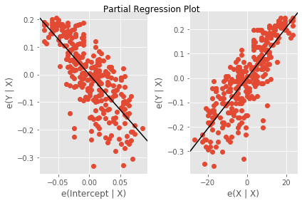

```python
sm.graphics.plot_partregress_grid(model2);
```

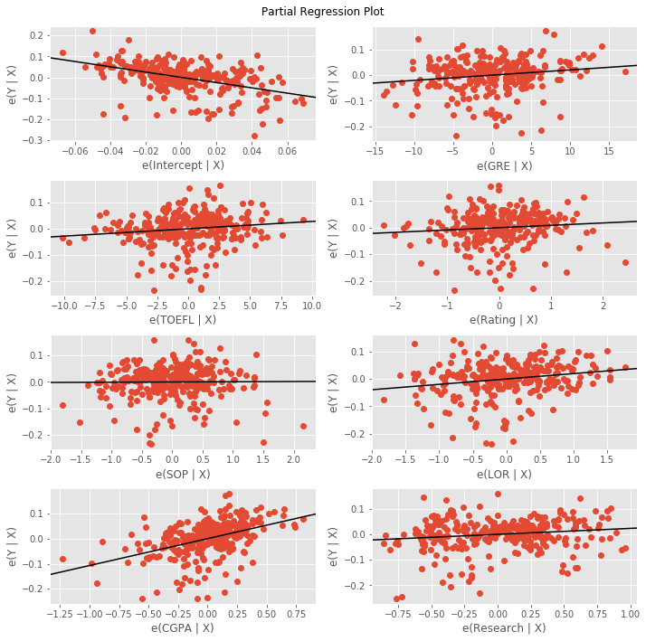

```python
fig = plt.figure(figsize=(10,10))

sm.graphics.plot_partregress_grid(model3, fig = fig);
```

# Problems arising in regression

Many potential problems arise in linear regression, and a large body of information, tips, and tricks has been created as a result. Rather than listing all possible problems and their candidate solutions, we'll just look at 4 problems identified in (James, Witten, Hastie, & Tibshirani, 2013).

1. The data shows non-linear relationships - it may be best to consider a non-linear model to describe the relationships in the data.
2. The errors in the prediction have non-constant variance - this shows up when the variance of a single error term depends on the value of the response variable $Y$. This is sometimes combated by transforming the response variable with logarithms or square root functions. Another solution is to use *weighted least squares*.
3. Outliers - if there is some mistake in the recorded value or the absence of the outlier doesn't significantly affect $R_a^2$, it is likely safe to remove the value. Sometimes, however, an outlier should stay in the dataset and will significantly affect the fit of the model. This leads to an investigation of *leverage statistics*, and further reading in (James, Witten, Hastie, & Tibshirani, 2013) is recommended.
4. Two or more predictor variables are related to one another - this can be detected by examining the covariance matrix for all predictor variables. If an entry of this matrix has a large absolute value, then the corresponding variables are related. We can work to solve this problem using PCA with all predictor variables and then fit the model on the de-correlated principal components.

```python
data.drop(['const','Y'], axis = 1).corr()
```

|  | GRE | TOEFL | Rating | SOP | LOR | CGPA | Research |
| --- | --- | --- | --- | --- | --- | --- | --- |
| GRE | 1.000000 | 0.827200 | 0.635376 | 0.613498 | 0.524679 | 0.825878 | 0.563398 |
| TOEFL | 0.827200 | 1.000000 | 0.649799 | 0.644410 | 0.541563 | 0.810574 | 0.467012 |
| Rating | 0.635376 | 0.649799 | 1.000000 | 0.728024 | 0.608651 | 0.705254 | 0.427047 |
| SOP | 0.613498 | 0.644410 | 0.728024 | 1.000000 | 0.663707 | 0.712154 | 0.408116 |
| LOR | 0.524679 | 0.541563 | 0.608651 | 0.663707 | 1.000000 | 0.637469 | 0.372526 |
| CGPA | 0.825878 | 0.810574 | 0.705254 | 0.712154 | 0.637469 | 1.000000 | 0.501311 |
| Research | 0.563398 | 0.467012 | 0.427047 | 0.408116 | 0.372526 | 0.501311 | 1.000000 |

# *Exercises*

These exercises use the `Advertising.csv` and `Credit.csv` datasets available on the companion website to [Introduction to Statistical Learning with applications in R](http://faculty.marshall.usc.edu/gareth-james/ISL/data.html).

1. Fit a simple linear regression model for the `Advertising.csv` dataset. Use `sales` as the $Y$-variable and `radio` as the predictor variable $X$. At each step, produce the necessary plots.

```python
advert = pd.read_csv('Advertising.csv', index_col = 0)
advert
```

|  | TV | radio | newspaper | sales |
| --- | --- | --- | --- | --- |
| 1 | 230.1 | 37.8 | 69.2 | 22.1 |
| 2 | 44.5 | 39.3 | 45.1 | 10.4 |
| 3 | 17.2 | 45.9 | 69.3 | 9.3 |
| 4 | 151.5 | 41.3 | 58.5 | 18.5 |
| 5 | 180.8 | 10.8 | 58.4 | 12.9 |
| ... | ... | ... | ... | ... |
| 196 | 38.2 | 3.7 | 13.8 | 7.6 |
| 197 | 94.2 | 4.9 | 8.1 | 9.7 |
| 198 | 177.0 | 9.3 | 6.4 | 12.8 |
| 199 | 283.6 | 42.0 | 66.2 | 25.5 |
| 200 | 232.1 | 8.6 | 8.7 | 13.4 |

200 rows × 4 columns

```python
advert.corr()
```

|  | TV | radio | newspaper | sales |
| --- | --- | --- | --- | --- |
| TV | 1.000000 | 0.054809 | 0.056648 | 0.782224 |
| radio | 0.054809 | 1.000000 | 0.354104 | 0.576223 |
| newspaper | 0.056648 | 0.354104 | 1.000000 | 0.228299 |
| sales | 0.782224 | 0.576223 | 0.228299 | 1.000000 |

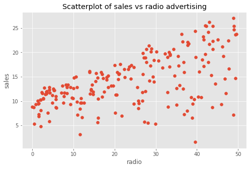

```python
fig, ax = plt.subplots(figsize = (8,5))

ax.scatter(advert['radio'], advert['sales']);
ax.set(title = 'Scatterplot of sales vs radio advertising',
       xlabel = 'radio',
       ylabel = 'sales');
```

```python
# Make sure we fit the intercept
advert = sm.add_constant(advert)

model5 = ols('sales ~ radio', data = advert).fit()
print(model5.summary())
```

```
                            OLS Regression Results
==============================================================================
Dep. Variable:                  sales   R-squared:                       0.332
Model:                            OLS   Adj. R-squared:                  0.329
Method:                 Least Squares   F-statistic:                     98.42
Date:                Wed, 25 Mar 2020   Prob (F-statistic):           4.35e-19
Time:                        20:13:46   Log-Likelihood:                -573.34
No. Observations:                 200   AIC:                             1151.
Df Residuals:                     198   BIC:                             1157.
Df Model:                           1
Covariance Type:            nonrobust
==============================================================================
                 coef    std err          t      P>|t|      [0.025      0.975]
------------------------------------------------------------------------------
Intercept      9.3116      0.563     16.542      0.000       8.202      10.422
radio          0.2025      0.020      9.921      0.000       0.162       0.243
==============================================================================
Omnibus:                       19.358   Durbin-Watson:                   1.946
Prob(Omnibus):                  0.000   Jarque-Bera (JB):               21.910
Skew:                          -0.764   Prob(JB):                     1.75e-05
Kurtosis:                       3.544   Cond. No.                         51.4
==============================================================================

Warnings:
[1] Standard Errors assume that the covariance matrix of the errors is correctly specified.
```

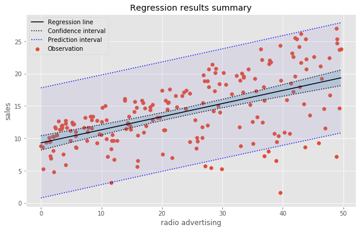

```python
predictions = model5.get_prediction(advert[['radio','const']]).summary_frame(alpha = 0.05)

# This defines the regression line
Y_pred = predictions['mean'].sort_values()

# These define the 95% confidence interval
ci_upper = predictions['mean_ci_upper'].sort_values()
ci_lower = predictions['mean_ci_lower'].sort_values()

# These define the prediction interval
pi_upper = predictions['obs_ci_upper'].sort_values()
pi_lower = predictions['obs_ci_lower'].sort_values()

X_plot = advert['radio'].sort_values()

fig, ax = plt.subplots(figsize = (10,6))

# Plot the observations
ax.scatter(advert['radio'], advert['sales'], marker = 'o', label = 'Observation');

# Plot the regression line
ax.plot(X_plot, Y_pred, 'k', label = 'Regression line');

# Plot the confidence interval
ax.plot(X_plot, ci_upper, 'k:');
ax.plot(X_plot, ci_lower, 'k:', label = 'Confidence interval');

# Plot the prediction interval
ax.plot(X_plot, pi_upper, 'b:');
ax.plot(X_plot, pi_lower, 'b:', label = 'Prediction interval');

plt.fill_between(X_plot, ci_lower, ci_upper, alpha = 0.25);
plt.fill_between(X_plot, pi_lower, pi_upper, alpha = 0.15);

ax.set(title = 'Regression results summary',
       xlabel = 'radio advertising',
       ylabel = 'sales');
ax.legend();
```

1. Fit the multiple regression model for the `Advertising.csv` dataset, using `sales` as $Y$.

```python
advert
```

|  | const | TV | radio | newspaper | sales |
| --- | --- | --- | --- | --- | --- |
| 1 | 1.0 | 230.1 | 37.8 | 69.2 | 22.1 |
| 2 | 1.0 | 44.5 | 39.3 | 45.1 | 10.4 |
| 3 | 1.0 | 17.2 | 45.9 | 69.3 | 9.3 |
| 4 | 1.0 | 151.5 | 41.3 | 58.5 | 18.5 |
| 5 | 1.0 | 180.8 | 10.8 | 58.4 | 12.9 |
| ... | ... | ... | ... | ... | ... |
| 196 | 1.0 | 38.2 | 3.7 | 13.8 | 7.6 |
| 197 | 1.0 | 94.2 | 4.9 | 8.1 | 9.7 |
| 198 | 1.0 | 177.0 | 9.3 | 6.4 | 12.8 |
| 199 | 1.0 | 283.6 | 42.0 | 66.2 | 25.5 |
| 200 | 1.0 | 232.1 | 8.6 | 8.7 | 13.4 |

200 rows × 5 columns

```python
model6 = ols('sales ~ TV + radio + newspaper', data = advert).fit()
print(model6.summary())
```

```
                            OLS Regression Results
==============================================================================
Dep. Variable:                  sales   R-squared:                       0.897
Model:                            OLS   Adj. R-squared:                  0.896
Method:                 Least Squares   F-statistic:                     570.3
Date:                Wed, 25 Mar 2020   Prob (F-statistic):           1.58e-96
Time:                        20:19:11   Log-Likelihood:                -386.18
No. Observations:                 200   AIC:                             780.4
Df Residuals:                     196   BIC:                             793.6
Df Model:                           3
Covariance Type:            nonrobust
==============================================================================
                 coef    std err          t      P>|t|      [0.025      0.975]
------------------------------------------------------------------------------
Intercept      2.9389      0.312      9.422      0.000       2.324       3.554
TV             0.0458      0.001     32.809      0.000       0.043       0.049
radio          0.1885      0.009     21.893      0.000       0.172       0.206
newspaper     -0.0010      0.006     -0.177      0.860      -0.013       0.011
==============================================================================
Omnibus:                       60.414   Durbin-Watson:                   2.084
Prob(Omnibus):                  0.000   Jarque-Bera (JB):              151.241
Skew:                          -1.327   Prob(JB):                     1.44e-33
Kurtosis:                       6.332   Cond. No.                         454.
==============================================================================

Warnings:
[1] Standard Errors assume that the covariance matrix of the errors is correctly specified.
```

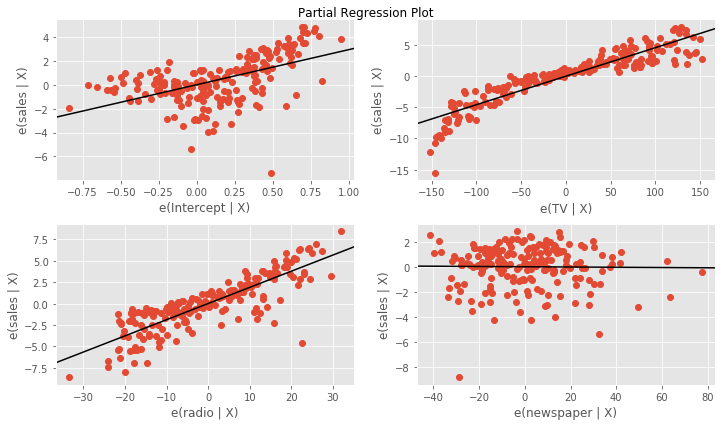

```python
fig = plt.figure(figsize=(10,6))

sm.graphics.plot_partregress_grid(model6, fig = fig);
```

1. Perform some exploratory data analysis on the `Credit.csv` dataset. Compute the summary statistics for the dataset, and also compute dummy variables for `Gender`, `Student`, `Married`, and `Ethnicity`. Determine if `Rating`, `Limit`, and `Income` are linearly related to `Balance`.

```python
credit = pd.read_csv('Credit.csv', index_col = 0)
credit
```

|  | Income | Limit | Rating | Cards | Age | Education | Gender | Student | Married | Ethnicity | Balance |
| --- | --- | --- | --- | --- | --- | --- | --- | --- | --- | --- | --- |
| 1 | 14.891 | 3606 | 283 | 2 | 34 | 11 | Male | No | Yes | Caucasian | 333 |
| 2 | 106.025 | 6645 | 483 | 3 | 82 | 15 | Female | Yes | Yes | Asian | 903 |
| 3 | 104.593 | 7075 | 514 | 4 | 71 | 11 | Male | No | No | Asian | 580 |
| 4 | 148.924 | 9504 | 681 | 3 | 36 | 11 | Female | No | No | Asian | 964 |
| 5 | 55.882 | 4897 | 357 | 2 | 68 | 16 | Male | No | Yes | Caucasian | 331 |
| ... | ... | ... | ... | ... | ... | ... | ... | ... | ... | ... | ... |
| 396 | 12.096 | 4100 | 307 | 3 | 32 | 13 | Male | No | Yes | Caucasian | 560 |
| 397 | 13.364 | 3838 | 296 | 5 | 65 | 17 | Male | No | No | African American | 480 |
| 398 | 57.872 | 4171 | 321 | 5 | 67 | 12 | Female | No | Yes | Caucasian | 138 |
| 399 | 37.728 | 2525 | 192 | 1 | 44 | 13 | Male | No | Yes | Caucasian | 0 |
| 400 | 18.701 | 5524 | 415 | 5 | 64 | 7 | Female | No | No | Asian | 966 |

400 rows × 11 columns

```python
credit.corr()
```

|  | Income | Limit | Rating | Cards | Age | Education | Balance |
| --- | --- | --- | --- | --- | --- | --- | --- |
| Income | 1.000000 | 0.792088 | 0.791378 | -0.018273 | 0.175338 | -0.027692 | 0.463656 |
| Limit | 0.792088 | 1.000000 | 0.996880 | 0.010231 | 0.100888 | -0.023549 | 0.861697 |
| Rating | 0.791378 | 0.996880 | 1.000000 | 0.053239 | 0.103165 | -0.030136 | 0.863625 |
| Cards | -0.018273 | 0.010231 | 0.053239 | 1.000000 | 0.042948 | -0.051084 | 0.086456 |
| Age | 0.175338 | 0.100888 | 0.103165 | 0.042948 | 1.000000 | 0.003619 | 0.001835 |
| Education | -0.027692 | -0.023549 | -0.030136 | -0.051084 | 0.003619 | 1.000000 | -0.008062 |
| Balance | 0.463656 | 0.861697 | 0.863625 | 0.086456 | 0.001835 | -0.008062 | 1.000000 |

```python
credit.describe()
```

|  | Income | Limit | Rating | Cards | Age | Education | Balance |
| --- | --- | --- | --- | --- | --- | --- | --- |
| count | 400.000000 | 400.000000 | 400.000000 | 400.000000 | 400.000000 | 400.000000 | 400.000000 |
| mean | 45.218885 | 4735.600000 | 354.940000 | 2.957500 | 55.667500 | 13.450000 | 520.015000 |
| std | 35.244273 | 2308.198848 | 154.724143 | 1.371275 | 17.249807 | 3.125207 | 459.758877 |
| min | 10.354000 | 855.000000 | 93.000000 | 1.000000 | 23.000000 | 5.000000 | 0.000000 |
| 25% | 21.007250 | 3088.000000 | 247.250000 | 2.000000 | 41.750000 | 11.000000 | 68.750000 |
| 50% | 33.115500 | 4622.500000 | 344.000000 | 3.000000 | 56.000000 | 14.000000 | 459.500000 |
| 75% | 57.470750 | 5872.750000 | 437.250000 | 4.000000 | 70.000000 | 16.000000 | 863.000000 |
| max | 186.634000 | 13913.000000 | 982.000000 | 9.000000 | 98.000000 | 20.000000 | 1999.000000 |

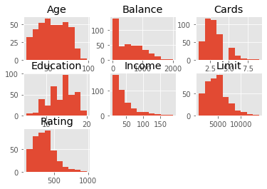

```python
credit.hist();
```

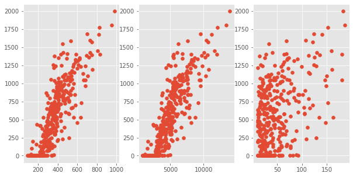

```python
credit = pd.get_dummies(credit, drop_first = True)

fig, ax = plt.subplots(1, 3, figsize = (10,5))

ax[0].scatter(credit['Rating'], credit['Balance']);
ax[1].scatter(credit['Limit'], credit['Balance']);
ax[2].scatter(credit['Income'], credit['Balance']);
```

1. Using the `Credit.csv` dataset, fit a multiple regression model using forward selection. Which predictor variables does the model keep?

# References

Acharya, Mohan S., Armaan, Asfia, & Antony, Aneeta S. (2019). A Comparison of Regression Models for Prediction of Graduate Admissions. *IEEE International Conference on Computational Intelligence in Data Science 2019*.

James, G., Witten, D., Hastie, T., & Tibshirani, R. (2013). An introduction to statistical learning (Vol. 112, pp. 3-7). New York: Springer.